# Risk Factor Analysis

## Outcome Variable

**Outcome Variable:** whz

## Predictor Variables

**Intervention Variable:** nhh

**Adjustment Set:**

- arm
- W_mage
- meducyrs
- feducyrs
- hhwealth_quart
- W_mhtcm
- W_mwtkg
- W_mbmi
- W_nrooms
- cleanck
- impfloor
- impsan
- safeh20
- delta_W_mage
- delta_meducyrs
- delta_feducyrs
- delta_hhwealth_quart
- delta_W_mhtcm
- delta_W_mwtkg
- delta_W_mbmi
- delta_W_nrooms
- delta_cleanck
- delta_impfloor
- delta_impsan
- delta_safeh20

## Stratifying Variables

The analysis was stratified on these variable(s):

- agecat
- studyid
- country

## Data Summary

| agecat | studyid | country | nhh | n_cell | n |
| --- | --- | --- | --- | --- | --- |
| Birth | ki1000108-IRC | INDIA | 3 or less | 52 | 343 |
| Birth | ki1000108-IRC | INDIA | 4-5 | 131 | 343 |
| Birth | ki1000108-IRC | INDIA | 6-7 | 84 | 343 |
| Birth | ki1000108-IRC | INDIA | 8+ | 76 | 343 |
| Birth | ki1017093-NIH-Birth | BANGLADESH | 3 or less | 7 | 28 |
| Birth | ki1017093-NIH-Birth | BANGLADESH | 4-5 | 11 | 28 |
| Birth | ki1017093-NIH-Birth | BANGLADESH | 6-7 | 7 | 28 |
| Birth | ki1017093-NIH-Birth | BANGLADESH | 8+ | 3 | 28 |
| Birth | ki1017093c-NIH-Crypto | BANGLADESH | 3 or less | 8 | 23 |
| Birth | ki1017093c-NIH-Crypto | BANGLADESH | 4-5 | 7 | 23 |
| Birth | ki1017093c-NIH-Crypto | BANGLADESH | 6-7 | 5 | 23 |
| Birth | ki1017093c-NIH-Crypto | BANGLADESH | 8+ | 3 | 23 |
| 6 months | ki1000108-IRC | INDIA | 3 or less | 57 | 408 |
| 6 months | ki1000108-IRC | INDIA | 4-5 | 157 | 408 |
| 6 months | ki1000108-IRC | INDIA | 6-7 | 107 | 408 |
| 6 months | ki1000108-IRC | INDIA | 8+ | 87 | 408 |
| 6 months | ki1000304b-SAS-FoodSuppl | INDIA | 3 or less | 33 | 380 |
| 6 months | ki1000304b-SAS-FoodSuppl | INDIA | 4-5 | 166 | 380 |
| 6 months | ki1000304b-SAS-FoodSuppl | INDIA | 6-7 | 115 | 380 |
| 6 months | ki1000304b-SAS-FoodSuppl | INDIA | 8+ | 66 | 380 |
| 6 months | ki1017093-NIH-Birth | BANGLADESH | 3 or less | 95 | 536 |
| 6 months | ki1017093-NIH-Birth | BANGLADESH | 4-5 | 227 | 536 |
| 6 months | ki1017093-NIH-Birth | BANGLADESH | 6-7 | 127 | 536 |
| 6 months | ki1017093-NIH-Birth | BANGLADESH | 8+ | 87 | 536 |
| 6 months | ki1017093b-PROVIDE | BANGLADESH | 3 or less | 102 | 582 |
| 6 months | ki1017093b-PROVIDE | BANGLADESH | 4-5 | 277 | 582 |
| 6 months | ki1017093b-PROVIDE | BANGLADESH | 6-7 | 126 | 582 |
| 6 months | ki1017093b-PROVIDE | BANGLADESH | 8+ | 77 | 582 |
| 6 months | ki1017093c-NIH-Crypto | BANGLADESH | 3 or less | 104 | 715 |
| 6 months | ki1017093c-NIH-Crypto | BANGLADESH | 4-5 | 326 | 715 |
| 6 months | ki1017093c-NIH-Crypto | BANGLADESH | 6-7 | 170 | 715 |
| 6 months | ki1017093c-NIH-Crypto | BANGLADESH | 8+ | 115 | 715 |
| 6 months | ki1148112-LCNI-5 | MALAWI | 3 or less | 224 | 816 |
| 6 months | ki1148112-LCNI-5 | MALAWI | 4-5 | 340 | 816 |
| 6 months | ki1148112-LCNI-5 | MALAWI | 6-7 | 182 | 816 |
| 6 months | ki1148112-LCNI-5 | MALAWI | 8+ | 70 | 816 |
| 24 months | ki1000108-IRC | INDIA | 3 or less | 58 | 409 |
| 24 months | ki1000108-IRC | INDIA | 4-5 | 158 | 409 |
| 24 months | ki1000108-IRC | INDIA | 6-7 | 107 | 409 |
| 24 months | ki1000108-IRC | INDIA | 8+ | 86 | 409 |
| 24 months | ki1017093-NIH-Birth | BANGLADESH | 3 or less | 74 | 428 |
| 24 months | ki1017093-NIH-Birth | BANGLADESH | 4-5 | 184 | 428 |
| 24 months | ki1017093-NIH-Birth | BANGLADESH | 6-7 | 100 | 428 |
| 24 months | ki1017093-NIH-Birth | BANGLADESH | 8+ | 70 | 428 |
| 24 months | ki1017093b-PROVIDE | BANGLADESH | 3 or less | 105 | 578 |
| 24 months | ki1017093b-PROVIDE | BANGLADESH | 4-5 | 273 | 578 |
| 24 months | ki1017093b-PROVIDE | BANGLADESH | 6-7 | 117 | 578 |
| 24 months | ki1017093b-PROVIDE | BANGLADESH | 8+ | 83 | 578 |
| 24 months | ki1017093c-NIH-Crypto | BANGLADESH | 3 or less | 69 | 514 |
| 24 months | ki1017093c-NIH-Crypto | BANGLADESH | 4-5 | 232 | 514 |
| 24 months | ki1017093c-NIH-Crypto | BANGLADESH | 6-7 | 130 | 514 |
| 24 months | ki1017093c-NIH-Crypto | BANGLADESH | 8+ | 83 | 514 |
| 24 months | ki1148112-LCNI-5 | MALAWI | 3 or less | 157 | 558 |
| 24 months | ki1148112-LCNI-5 | MALAWI | 4-5 | 230 | 558 |
| 24 months | ki1148112-LCNI-5 | MALAWI | 6-7 | 123 | 558 |
| 24 months | ki1148112-LCNI-5 | MALAWI | 8+ | 48 | 558 |

The following strata were considered:

- agecat: 24 months, studyid: ki1000108-IRC, country: INDIA
- agecat: 24 months, studyid: ki1017093-NIH-Birth, country: BANGLADESH
- agecat: 24 months, studyid: ki1017093b-PROVIDE, country: BANGLADESH
- agecat: 24 months, studyid: ki1017093c-NIH-Crypto, country: BANGLADESH
- agecat: 24 months, studyid: ki1148112-LCNI-5, country: MALAWI
- agecat: 6 months, studyid: ki1000108-IRC, country: INDIA
- agecat: 6 months, studyid: ki1000304b-SAS-FoodSuppl, country: INDIA
- agecat: 6 months, studyid: ki1017093-NIH-Birth, country: BANGLADESH
- agecat: 6 months, studyid: ki1017093b-PROVIDE, country: BANGLADESH
- agecat: 6 months, studyid: ki1017093c-NIH-Crypto, country: BANGLADESH
- agecat: 6 months, studyid: ki1148112-LCNI-5, country: MALAWI
- agecat: Birth, studyid: ki1000108-IRC, country: INDIA
- agecat: Birth, studyid: ki1017093-NIH-Birth, country: BANGLADESH
- agecat: Birth, studyid: ki1017093c-NIH-Crypto, country: BANGLADESH

### Dropped Strata

Some strata were dropped due to rare outcomes:

- agecat: Birth, studyid: ki1017093-NIH-Birth, country: BANGLADESH
- agecat: Birth, studyid: ki1017093c-NIH-Crypto, country: BANGLADESH

## Methods Detail

We’re interested in the causal parameters $E[Y_a]$ for all values of $a \in \mathcal{A}$. These parameters represent the mean outcome if, possibly contrary to fact, we intervened to set all units to have $A=a$. Under the randomization and positivity assumptions, these are identified by the statistical parameters $\psi_a=E_W[E_{Y|A,W}(Y|A=a,W)]$. In addition, we’re interested in the mean of $Y$, $E[Y]$ under no intervention (the observed mean). We will estimate these parameters by using SuperLearner to fit the relevant likelihood factors – $E_{Y|A,W}(Y|A=a,W)$ and $p(A=a|W)$, and then updating our likelihood fit using a joint TMLE.

For unadjusted analyses ($W=\{\}$), initial likelihoods were estimated using Lrnr_glm to estimate the simple $E(Y|A)$ and Lrnr_mean to estimate $p(A)$. For adjusted analyses, a small library containing Lrnr_glmnet, Lrnr_xgboost, and Lrnr_mean was used.

Having estimated these parameters, we will then use the delta method to estimate relative risks and attributable risks relative to a prespecified baseline level of $A$.

# Results Detail

## Results Plots

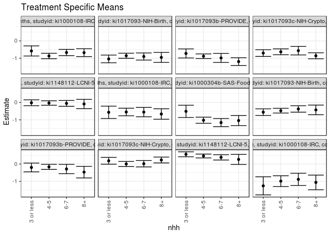

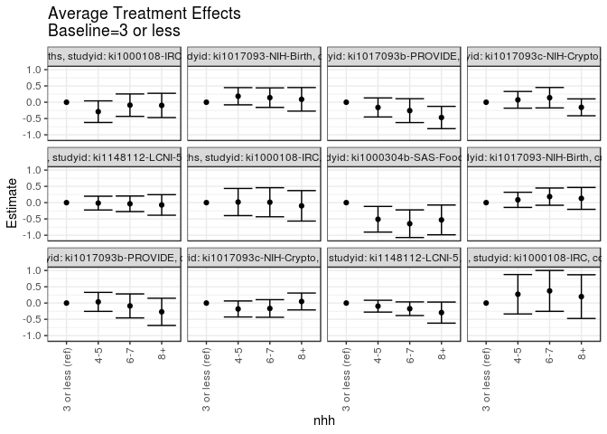

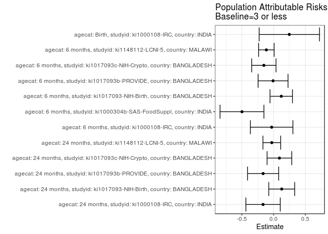

## Results Table

### Parameter: TSM

| agecat | studyid | country | intervention_level | baseline_level | estimate | ci_lower | ci_upper |
| --- | --- | --- | --- | --- | --- | --- | --- |
| Birth | ki1000108-IRC | INDIA | 3 or less | NA | -1.2585854 | -1.7787593 | -0.7384115 |
| Birth | ki1000108-IRC | INDIA | 4-5 | NA | -0.9883125 | -1.2983077 | -0.6783172 |
| Birth | ki1000108-IRC | INDIA | 6-7 | NA | -0.8858206 | -1.2373765 | -0.5342648 |
| Birth | ki1000108-IRC | INDIA | 8+ | NA | -1.0609676 | -1.4832118 | -0.6387233 |
| 6 months | ki1000108-IRC | INDIA | 3 or less | NA | -0.5687514 | -0.9249828 | -0.2125201 |
| 6 months | ki1000108-IRC | INDIA | 4-5 | NA | -0.5501891 | -0.7683350 | -0.3320433 |
| 6 months | ki1000108-IRC | INDIA | 6-7 | NA | -0.5567444 | -0.8263311 | -0.2871578 |
| 6 months | ki1000108-IRC | INDIA | 8+ | NA | -0.6668621 | -0.9662521 | -0.3674721 |
| 6 months | ki1000304b-SAS-FoodSuppl | INDIA | 3 or less | NA | -0.5138257 | -0.8670574 | -0.1605940 |
| 6 months | ki1000304b-SAS-FoodSuppl | INDIA | 4-5 | NA | -1.0235674 | -1.1986795 | -0.8484552 |
| 6 months | ki1000304b-SAS-FoodSuppl | INDIA | 6-7 | NA | -1.1601572 | -1.3935862 | -0.9267283 |
| 6 months | ki1000304b-SAS-FoodSuppl | INDIA | 8+ | NA | -1.0433930 | -1.3340734 | -0.7527126 |
| 6 months | ki1017093-NIH-Birth | BANGLADESH | 3 or less | NA | -0.5603768 | -0.7506566 | -0.3700971 |
| 6 months | ki1017093-NIH-Birth | BANGLADESH | 4-5 | NA | -0.4738172 | -0.6095207 | -0.3381136 |
| 6 months | ki1017093-NIH-Birth | BANGLADESH | 6-7 | NA | -0.3757716 | -0.5609623 | -0.1905809 |
| 6 months | ki1017093-NIH-Birth | BANGLADESH | 8+ | NA | -0.4300080 | -0.7079245 | -0.1520915 |
| 6 months | ki1017093b-PROVIDE | BANGLADESH | 3 or less | NA | -0.2005065 | -0.4524221 | 0.0514092 |
| 6 months | ki1017093b-PROVIDE | BANGLADESH | 4-5 | NA | -0.1645632 | -0.3118056 | -0.0173208 |
| 6 months | ki1017093b-PROVIDE | BANGLADESH | 6-7 | NA | -0.2880121 | -0.5565495 | -0.0194747 |
| 6 months | ki1017093b-PROVIDE | BANGLADESH | 8+ | NA | -0.4703423 | -0.8040432 | -0.1366415 |
| 6 months | ki1017093c-NIH-Crypto | BANGLADESH | 3 or less | NA | 0.1829679 | -0.0133445 | 0.3792803 |
| 6 months | ki1017093c-NIH-Crypto | BANGLADESH | 4-5 | NA | 0.0013382 | -0.1462751 | 0.1489515 |
| 6 months | ki1017093c-NIH-Crypto | BANGLADESH | 6-7 | NA | 0.0166413 | -0.1690173 | 0.2022998 |
| 6 months | ki1017093c-NIH-Crypto | BANGLADESH | 8+ | NA | 0.2308927 | 0.0621179 | 0.3996674 |
| 6 months | ki1148112-LCNI-5 | MALAWI | 3 or less | NA | 0.5554855 | 0.4124176 | 0.6985534 |
| 6 months | ki1148112-LCNI-5 | MALAWI | 4-5 | NA | 0.4595652 | 0.3478628 | 0.5712676 |
| 6 months | ki1148112-LCNI-5 | MALAWI | 6-7 | NA | 0.3816781 | 0.2293801 | 0.5339762 |
| 6 months | ki1148112-LCNI-5 | MALAWI | 8+ | NA | 0.2623333 | -0.0278945 | 0.5525612 |
| 24 months | ki1000108-IRC | INDIA | 3 or less | NA | -0.5801081 | -0.8722973 | -0.2879188 |
| 24 months | ki1000108-IRC | INDIA | 4-5 | NA | -0.8699368 | -1.0265509 | -0.7133227 |
| 24 months | ki1000108-IRC | INDIA | 6-7 | NA | -0.6697158 | -0.8498508 | -0.4895809 |
| 24 months | ki1000108-IRC | INDIA | 8+ | NA | -0.6777228 | -0.9043621 | -0.4510835 |
| 24 months | ki1017093-NIH-Birth | BANGLADESH | 3 or less | NA | -1.0398388 | -1.2629388 | -0.8167389 |
| 24 months | ki1017093-NIH-Birth | BANGLADESH | 4-5 | NA | -0.8549549 | -1.0020072 | -0.7079026 |
| 24 months | ki1017093-NIH-Birth | BANGLADESH | 6-7 | NA | -0.8990672 | -1.1030375 | -0.6950969 |
| 24 months | ki1017093-NIH-Birth | BANGLADESH | 8+ | NA | -0.9511570 | -1.2384671 | -0.6638470 |
| 24 months | ki1017093b-PROVIDE | BANGLADESH | 3 or less | NA | -0.7231807 | -0.9846289 | -0.4617325 |
| 24 months | ki1017093b-PROVIDE | BANGLADESH | 4-5 | NA | -0.8836190 | -1.0159031 | -0.7513349 |
| 24 months | ki1017093b-PROVIDE | BANGLADESH | 6-7 | NA | -0.9814618 | -1.2398574 | -0.7230661 |
| 24 months | ki1017093b-PROVIDE | BANGLADESH | 8+ | NA | -1.1916301 | -1.4145323 | -0.9687279 |
| 24 months | ki1017093c-NIH-Crypto | BANGLADESH | 3 or less | NA | -0.7024579 | -0.8951217 | -0.5097942 |
| 24 months | ki1017093c-NIH-Crypto | BANGLADESH | 4-5 | NA | -0.6283952 | -0.7971218 | -0.4596686 |
| 24 months | ki1017093c-NIH-Crypto | BANGLADESH | 6-7 | NA | -0.5638115 | -0.8113426 | -0.3162803 |
| 24 months | ki1017093c-NIH-Crypto | BANGLADESH | 8+ | NA | -0.8588838 | -1.0316473 | -0.6861203 |
| 24 months | ki1148112-LCNI-5 | MALAWI | 3 or less | NA | -0.0196759 | -0.1884204 | 0.1490686 |
| 24 months | ki1148112-LCNI-5 | MALAWI | 4-5 | NA | -0.0336392 | -0.1613035 | 0.0940252 |
| 24 months | ki1148112-LCNI-5 | MALAWI | 6-7 | NA | -0.0551824 | -0.2231297 | 0.1127649 |
| 24 months | ki1148112-LCNI-5 | MALAWI | 8+ | NA | -0.0901559 | -0.3581474 | 0.1778355 |

### Parameter: E(Y)

| agecat | studyid | country | intervention_level | baseline_level | estimate | ci_lower | ci_upper |
| --- | --- | --- | --- | --- | --- | --- | --- |
| Birth | ki1000108-IRC | INDIA | NA | NA | -1.0105831 | -1.1973019 | -0.8238643 |
| 6 months | ki1000108-IRC | INDIA | NA | NA | -0.5989297 | -0.7344491 | -0.4634104 |
| 6 months | ki1000304b-SAS-FoodSuppl | INDIA | NA | NA | -1.0121579 | -1.1280429 | -0.8962729 |
| 6 months | ki1017093-NIH-Birth | BANGLADESH | NA | NA | -0.4389101 | -0.5279432 | -0.3498771 |
| 6 months | ki1017093b-PROVIDE | BANGLADESH | NA | NA | -0.2083706 | -0.2927992 | -0.1239419 |
| 6 months | ki1017093c-NIH-Crypto | BANGLADESH | NA | NA | 0.0297622 | -0.0491685 | 0.1086930 |
| 6 months | ki1148112-LCNI-5 | MALAWI | NA | NA | 0.4418137 | 0.3703100 | 0.5133174 |
| 24 months | ki1000108-IRC | INDIA | NA | NA | -0.7458150 | -0.8368180 | -0.6548120 |
| 24 months | ki1017093-NIH-Birth | BANGLADESH | NA | NA | -0.9115790 | -1.0095022 | -0.8136559 |
| 24 months | ki1017093b-PROVIDE | BANGLADESH | NA | NA | -0.8879412 | -0.9708680 | -0.8050144 |
| 24 months | ki1017093c-NIH-Crypto | BANGLADESH | NA | NA | -0.6103502 | -0.7050157 | -0.5156847 |
| 24 months | ki1148112-LCNI-5 | MALAWI | NA | NA | -0.0478674 | -0.1301904 | 0.0344557 |

### Parameter: ATE

| agecat | studyid | country | intervention_level | baseline_level | estimate | ci_lower | ci_upper |
| --- | --- | --- | --- | --- | --- | --- | --- |
| Birth | ki1000108-IRC | INDIA | 3 or less | 3 or less | 0.0000000 | 0.0000000 | 0.0000000 |
| Birth | ki1000108-IRC | INDIA | 4-5 | 3 or less | 0.2702729 | -0.3342424 | 0.8747883 |
| Birth | ki1000108-IRC | INDIA | 6-7 | 3 or less | 0.3727648 | -0.2544646 | 0.9999941 |
| Birth | ki1000108-IRC | INDIA | 8+ | 3 or less | 0.1976178 | -0.4737217 | 0.8689574 |
| 6 months | ki1000108-IRC | INDIA | 3 or less | 3 or less | 0.0000000 | 0.0000000 | 0.0000000 |
| 6 months | ki1000108-IRC | INDIA | 4-5 | 3 or less | 0.0185623 | -0.3983065 | 0.4354311 |
| 6 months | ki1000108-IRC | INDIA | 6-7 | 3 or less | 0.0120070 | -0.4344954 | 0.4585094 |
| 6 months | ki1000108-IRC | INDIA | 8+ | 3 or less | -0.0981106 | -0.5658655 | 0.3696442 |
| 6 months | ki1000304b-SAS-FoodSuppl | INDIA | 3 or less | 3 or less | 0.0000000 | 0.0000000 | 0.0000000 |
| 6 months | ki1000304b-SAS-FoodSuppl | INDIA | 4-5 | 3 or less | -0.5097417 | -0.9040297 | -0.1154537 |
| 6 months | ki1000304b-SAS-FoodSuppl | INDIA | 6-7 | 3 or less | -0.6463316 | -1.0703383 | -0.2223248 |
| 6 months | ki1000304b-SAS-FoodSuppl | INDIA | 8+ | 3 or less | -0.5295673 | -0.9867603 | -0.0723743 |
| 6 months | ki1017093-NIH-Birth | BANGLADESH | 3 or less | 3 or less | 0.0000000 | 0.0000000 | 0.0000000 |
| 6 months | ki1017093-NIH-Birth | BANGLADESH | 4-5 | 3 or less | 0.0865597 | -0.1462271 | 0.3193464 |
| 6 months | ki1017093-NIH-Birth | BANGLADESH | 6-7 | 3 or less | 0.1846052 | -0.0800607 | 0.4492711 |
| 6 months | ki1017093-NIH-Birth | BANGLADESH | 8+ | 3 or less | 0.1303688 | -0.2054198 | 0.4661574 |
| 6 months | ki1017093b-PROVIDE | BANGLADESH | 3 or less | 3 or less | 0.0000000 | 0.0000000 | 0.0000000 |
| 6 months | ki1017093b-PROVIDE | BANGLADESH | 4-5 | 3 or less | 0.0359433 | -0.2554368 | 0.3273233 |
| 6 months | ki1017093b-PROVIDE | BANGLADESH | 6-7 | 3 or less | -0.0875056 | -0.4556581 | 0.2806469 |
| 6 months | ki1017093b-PROVIDE | BANGLADESH | 8+ | 3 or less | -0.2698358 | -0.6872228 | 0.1475511 |
| 6 months | ki1017093c-NIH-Crypto | BANGLADESH | 3 or less | 3 or less | 0.0000000 | 0.0000000 | 0.0000000 |
| 6 months | ki1017093c-NIH-Crypto | BANGLADESH | 4-5 | 3 or less | -0.1816297 | -0.4271582 | 0.0638988 |
| 6 months | ki1017093c-NIH-Crypto | BANGLADESH | 6-7 | 3 or less | -0.1663266 | -0.4362833 | 0.1036301 |
| 6 months | ki1017093c-NIH-Crypto | BANGLADESH | 8+ | 3 or less | 0.0479248 | -0.2112175 | 0.3070671 |
| 6 months | ki1148112-LCNI-5 | MALAWI | 3 or less | 3 or less | 0.0000000 | 0.0000000 | 0.0000000 |
| 6 months | ki1148112-LCNI-5 | MALAWI | 4-5 | 3 or less | -0.0959203 | -0.2775424 | 0.0857018 |
| 6 months | ki1148112-LCNI-5 | MALAWI | 6-7 | 3 or less | -0.1738074 | -0.3830220 | 0.0354072 |
| 6 months | ki1148112-LCNI-5 | MALAWI | 8+ | 3 or less | -0.2931522 | -0.6169084 | 0.0306040 |
| 24 months | ki1000108-IRC | INDIA | 3 or less | 3 or less | 0.0000000 | 0.0000000 | 0.0000000 |
| 24 months | ki1000108-IRC | INDIA | 4-5 | 3 or less | -0.2898288 | -0.6217131 | 0.0420556 |
| 24 months | ki1000108-IRC | INDIA | 6-7 | 3 or less | -0.0896078 | -0.4338193 | 0.2546038 |
| 24 months | ki1000108-IRC | INDIA | 8+ | 3 or less | -0.0976148 | -0.4703661 | 0.2751366 |
| 24 months | ki1017093-NIH-Birth | BANGLADESH | 3 or less | 3 or less | 0.0000000 | 0.0000000 | 0.0000000 |
| 24 months | ki1017093-NIH-Birth | BANGLADESH | 4-5 | 3 or less | 0.1848840 | -0.0793325 | 0.4491004 |
| 24 months | ki1017093-NIH-Birth | BANGLADESH | 6-7 | 3 or less | 0.1407717 | -0.1592435 | 0.4407868 |
| 24 months | ki1017093-NIH-Birth | BANGLADESH | 8+ | 3 or less | 0.0886818 | -0.2732774 | 0.4506410 |
| 24 months | ki1017093b-PROVIDE | BANGLADESH | 3 or less | 3 or less | 0.0000000 | 0.0000000 | 0.0000000 |
| 24 months | ki1017093b-PROVIDE | BANGLADESH | 4-5 | 3 or less | -0.1604383 | -0.4527414 | 0.1318648 |
| 24 months | ki1017093b-PROVIDE | BANGLADESH | 6-7 | 3 or less | -0.2582811 | -0.6247633 | 0.1082011 |
| 24 months | ki1017093b-PROVIDE | BANGLADESH | 8+ | 3 or less | -0.4684494 | -0.8107258 | -0.1261730 |
| 24 months | ki1017093c-NIH-Crypto | BANGLADESH | 3 or less | 3 or less | 0.0000000 | 0.0000000 | 0.0000000 |
| 24 months | ki1017093c-NIH-Crypto | BANGLADESH | 4-5 | 3 or less | 0.0740628 | -0.1819795 | 0.3301050 |
| 24 months | ki1017093c-NIH-Crypto | BANGLADESH | 6-7 | 3 or less | 0.1386465 | -0.1753247 | 0.4526176 |
| 24 months | ki1017093c-NIH-Crypto | BANGLADESH | 8+ | 3 or less | -0.1564259 | -0.4153130 | 0.1024613 |
| 24 months | ki1148112-LCNI-5 | MALAWI | 3 or less | 3 or less | 0.0000000 | 0.0000000 | 0.0000000 |
| 24 months | ki1148112-LCNI-5 | MALAWI | 4-5 | 3 or less | -0.0139633 | -0.2257610 | 0.1978344 |
| 24 months | ki1148112-LCNI-5 | MALAWI | 6-7 | 3 or less | -0.0355065 | -0.2742408 | 0.2032278 |
| 24 months | ki1148112-LCNI-5 | MALAWI | 8+ | 3 or less | -0.0704801 | -0.3863126 | 0.2453525 |

### Parameter: PAR

| agecat | studyid | country | intervention_level | baseline_level | estimate | ci_lower | ci_upper |
| --- | --- | --- | --- | --- | --- | --- | --- |
| Birth | ki1000108-IRC | INDIA | 3 or less | NA | 0.2480023 | -0.2272318 | 0.7232364 |
| 6 months | ki1000108-IRC | INDIA | 3 or less | NA | -0.0301783 | -0.3654455 | 0.3050890 |
| 6 months | ki1000304b-SAS-FoodSuppl | INDIA | 3 or less | NA | -0.4983322 | -0.8442865 | -0.1523780 |
| 6 months | ki1017093-NIH-Birth | BANGLADESH | 3 or less | NA | 0.1214667 | -0.0557165 | 0.2986499 |
| 6 months | ki1017093b-PROVIDE | BANGLADESH | 3 or less | NA | -0.0078641 | -0.2438854 | 0.2281572 |
| 6 months | ki1017093c-NIH-Crypto | BANGLADESH | 3 or less | NA | -0.1532056 | -0.3448990 | 0.0384877 |
| 6 months | ki1148112-LCNI-5 | MALAWI | 3 or less | NA | -0.1136718 | -0.2358954 | 0.0085519 |
| 24 months | ki1000108-IRC | INDIA | 3 or less | NA | -0.1657069 | -0.4368574 | 0.1054435 |
| 24 months | ki1017093-NIH-Birth | BANGLADESH | 3 or less | NA | 0.1282598 | -0.0760056 | 0.3325252 |
| 24 months | ki1017093b-PROVIDE | BANGLADESH | 3 or less | NA | -0.1647605 | -0.4097141 | 0.0801931 |
| 24 months | ki1017093c-NIH-Crypto | BANGLADESH | 3 or less | NA | 0.0921078 | -0.1021194 | 0.2863349 |
| 24 months | ki1148112-LCNI-5 | MALAWI | 3 or less | NA | -0.0281915 | -0.1678599 | 0.1114768 |